# Case Study_01

Daniel Clark & Grace Lang

6/15/2019

# Anheuser-Busch InBev Nationwide Distillery Analysis

## Introduction

U.S. Beer Market is growing more saturated with small-scale breweries taking more market share and shelf space from the National Domestic Beer Manufacturers. Newer brands are covering the spectrum of bitterness and gravity size, and they are beginning to spread across the country. As AB Inbev is looking to test the waters in the craft brew space, understanding the local trends with these factors may help open market deficiencies as well as locations that may enjoy a bitter beer over others. This information can help guide AB Inbev with insight to opening new chains of micro-brews around the country.

## Loading our data

Budweiser supplied a large amount of data of Breweries around the US, Microbrew beers and some data on the alcohol by volume (ABV) and Bitterness score (IBU). We will be able to utilize this code to capture some insights on some factors enjoyed by beer drinkers around the country.

Load the code chunks from CSV files saved on Github’s site. There are two seperate files; one of breweries in the US and the second on the Beers sold at microbrews.

```r
library(dplyr)
library(tidyverse)
```

```r
library(ggplot2)
library(stats)

BeersCSV <- "https://raw.githubusercontent.com/BivinSadler/MSDS-6306-Doing-Data-Science/master/Unit%207/Beers.csv"
Beers <- read.csv(url(BeersCSV))

BrewCSV <- "https://raw.githubusercontent.com/BivinSadler/MSDS-6306-Doing-Data-Science/master/Unit%207/Breweries.csv"
Brew <- read.csv(url(BrewCSV))
```

## Reviewing Duplicates

This highlights the duplicated breweries on the list and finds the information on that is duplicated.

```r
Brew$Name[duplicated(Brew$Name)]
```

```
## [1] Blackrocks Brewery      Summit Brewing Company  Otter Creek Brewing
## [4] Sly Fox Brewing Company Blue Mountain Brewery   Lucette Brewing Company
## [7] Oskar Blues Brewery
## 551 Levels: 10 Barrel Brewing Company ... Wynkoop Brewing Company
```

```r
#checking our dataframe, we can identify some duplicates in our dataset. Let's investigate further to see if any need to be removed.
Brew[Brew$Name=='Blackrocks Brewery',] # appears that flying sailor is a part of the MI blackrocks, so combine them
```

```
##    Brew_ID               Name      City State
## 13      13 Blackrocks Brewery Marquette    MI
## 96      96 Blackrocks Brewery Marquette    MA
```

```r
Brew[Brew$Name=='Summit Brewing Company',] # both appear to be the same brewery, so combine 159 into 39
```

```
##     Brew_ID                   Name     City State
## 59       59 Summit Brewing Company St. Paul    MN
## 139     139 Summit Brewing Company  St Paul    MN
```

```r
Brew[Brew$Name=='Otter Creek Brewing',] # looks like middlebury is the correct location
```

```
##     Brew_ID                Name       City State
## 262     262 Otter Creek Brewing  Waterbury    VT
## 276     276 Otter Creek Brewing Middlebury    VT
```

```r
Brew[Brew$Name=='Sly Fox Brewing Company',] # this appears to be two actual locations of the same brewery, so let's leave as is, same state
```

```
##     Brew_ID                    Name         City State
## 164     164 Sly Fox Brewing Company Phoenixville    PA
## 372     372 Sly Fox Brewing Company    Pottstown    PA
```

```r
Brew[Brew$Name=='Blue Mountain Brewery',] #appears to be two locations of the same brewery. Keep as is for now, same state
```

```
##     Brew_ID                  Name      City State
## 383     383 Blue Mountain Brewery     Afton    VA
## 415     415 Blue Mountain Brewery Arrington    VA
```

```r
Brew[Brew$Name=='Lucette Brewing Company',] # looks like the correct spelling of the city is Monomonie, so we'll need to change the other
```

```
##     Brew_ID                    Name      City State
## 378     378 Lucette Brewing Company Menominee    WI
## 457     457 Lucette Brewing Company Menominie    WI
```

```r
Brew[Brew$Name=='Oskar Blues Brewery',] #looks like the correct location is longmont
```

```
##     Brew_ID                Name     City State
## 167     167 Oskar Blues Brewery Longmont    CO
## 504     504 Oskar Blues Brewery    Lyons    CO
```

## Tidying our data

We are merging the Brewery and Beer data by the Brewery ID numbers. We corrected some of the identification errors with some of the BrewID numbers and names.

```r
colnames(Beers)[colnames(Beers)=="Brewery_id"] <- "Brew_ID" #Rename for the same key
Combined <- merge(Beers, Brew, by = "Brew_ID") # Merge files
colnames(Combined)[colnames(Combined)=="Name.x"] <- "Beer Name"
colnames(Combined)[colnames(Combined)=="Name.y"] <- "Brewery_Name"


#Combining the duplicate Breweries into one Brew_ID and fixing some data entry issues, proved by Google searches
Combined[Combined$Brew_ID == '96',"Brew_ID"] <- 13
Combined$State <- as.character(Combined$State) #refactoring the whole column, so insert should work
Combined[Combined$Beer_ID == 2449 ,"State"] <- "MI" ## needs work, throwing error 'invalid factor level, NA generated'
Combined[Combined$Brew_ID == '139',"Brew_ID"] <- 59
Combined[Combined$Beer_ID == 2352 ,"City"] <- "St. Paul"
Combined[Combined$Brew_ID == '262',"Brew_ID"] <- 276
Combined[Combined$Brew_ID == 276 ,"City"] <- "Middlebury"
Combined[Combined$Brew_ID == '378',"Brew_ID"] <- 457
Combined$City <- as.character(Combined$City) #refactoring the whole column, so insert should work
Combined[Combined$Beer_ID == 1571 ,"City"] <- "Menomonie"
Combined[Combined$Brew_ID == '504',"Brew_ID"] <- 167
Combined[Combined$Brew_ID == 167 ,"City"] <- "Longmont"


n_distinct(Combined$Brew_ID) #Counting Breweries
```

```
## [1] 553
```

```r
n_distinct(Combined$Beer_ID) #Counting # of Beers
```

```
## [1] 2410
```

## Breweries per state

Utilizing R Code, we group the breweries by the state and count how many microbrews are present in each. Our code creates plots of the brewery by state into a bar graph for better visibility.

Now that our data is clean, let’s start looking at the number of Breweries by State. Looking at the data holistically, we can see that there is quite a range of breweries by state in the US. The most being Colorado with more than 45 and the least being a tie between Washington DC, North Dakota, South Dakota and West Virginia.

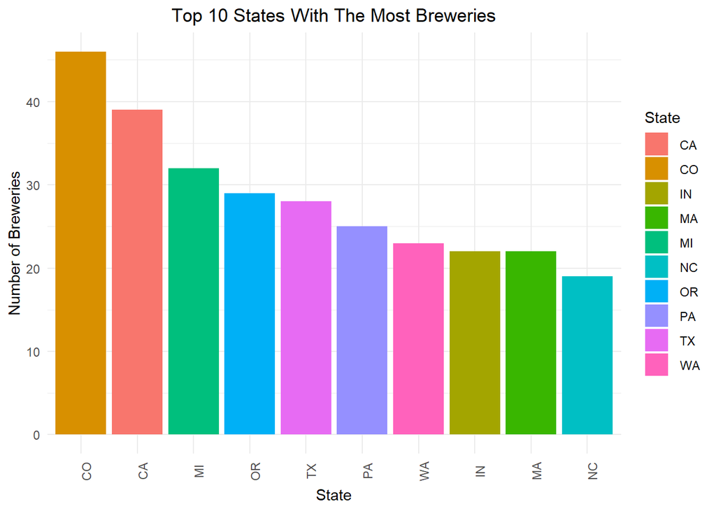

```r
BreweryByState <- Combined %>% group_by(State) %>%dplyr::summarise(StateCount = n_distinct(Brew_ID))
BreweryByState <- BreweryByState[order(-BreweryByState$StateCount),]

#Subsetting the data into top/bottoms
Top10 = subset(BreweryByState[1:10,])
Bottom10 = subset(BreweryByState[42:51,])

#Top 10 Graph
ggplot(Top10, aes(x=reorder(State,-StateCount),y=StateCount,fill=State) ) + geom_bar(stat = "identity") + theme_minimal() + theme(axis.text.x = element_text(angle=90),plot.title = element_text(hjust=0.5)) + labs(x="State", y="Number of Breweries", title = "Top 10 States With The Most Breweries")
```

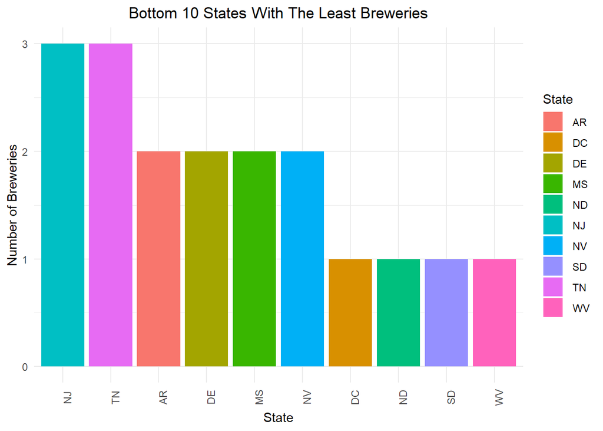

```r
#Bottom 10 Graph
ggplot(Bottom10, aes(x=reorder(State,-StateCount),y=StateCount,fill=State)) + geom_bar(stat = "identity") + theme_minimal() + theme(axis.text.x = element_text(angle=90),plot.title = element_text(hjust=0.5)) + labs(x="State", y="Number of Breweries", title = "Bottom 10 States With The Least Breweries")
```

```r
# full plot
#ggplot(BreweryByState, aes(x=reorder(State,-StateCount),y=StateCount,fill=State)) + geom_bar(stat = "identity") + theme_minimal() + theme(axis.text.x = element_text(angle=90, size=7),plot.title = element_text(hjust=0.5)) + labs(x="State", y="Number of Breweries", title = "Top States With The Most Breweries")
##data check for 558
#sum(BreweryByState$StateCount)
```

## Reviewing nature of our combined data

Reviews the top 6 and bottom six lines of data on the combined dataset.

```r
head(Combined,n=6)
```

```
##   Brew_ID     Beer Name Beer_ID   ABV IBU
## 1       1  Get Together    2692 0.045  50
## 2       1 Maggie's Leap    2691 0.049  26
## 3       1    Wall's End    2690 0.048  19
## 4       1       Pumpion    2689 0.060  38
## 5       1    Stronghold    2688 0.060  25
## 6       1   Parapet ESB    2687 0.056  47
##                                 Style Ounces       Brewery_Name
## 1                        American IPA     16 NorthGate Brewing
## 2                  Milk / Sweet Stout     16 NorthGate Brewing
## 3                   English Brown Ale     16 NorthGate Brewing
## 4                         Pumpkin Ale     16 NorthGate Brewing
## 5                     American Porter     16 NorthGate Brewing
## 6 Extra Special / Strong Bitter (ESB)     16 NorthGate Brewing
##          City State
## 1 Minneapolis    MN
## 2 Minneapolis    MN
## 3 Minneapolis    MN
## 4 Minneapolis    MN
## 5 Minneapolis    MN
## 6 Minneapolis    MN
```

```r
tail(Combined,n=6)
```

```
##      Brew_ID                 Beer Name Beer_ID   ABV IBU
## 2405     556             Pilsner Ukiah      98 0.055  NA
## 2406     557  Heinnieweisse Weissebier      52 0.049  NA
## 2407     557           Snapperhead IPA      51 0.068  NA
## 2408     557         Moo Thunder Stout      50 0.049  NA
## 2409     557         Porkslap Pale Ale      49 0.043  NA
## 2410     558 Urban Wilderness Pale Ale      30 0.049  NA
##                        Style Ounces                  Brewery_Name
## 2405         German Pilsener     12         Ukiah Brewing Company
## 2406              Hefeweizen     12       Butternuts Beer and Ale
## 2407            American IPA     12       Butternuts Beer and Ale
## 2408      Milk / Sweet Stout     12       Butternuts Beer and Ale
## 2409 American Pale Ale (APA)     12       Butternuts Beer and Ale
## 2410        English Pale Ale     12 Sleeping Lady Brewing Company
##               City State
## 2405         Ukiah    CA
## 2406 Garrattsville    NY
## 2407 Garrattsville    NY
## 2408 Garrattsville    NY
## 2409 Garrattsville    NY
## 2410     Anchorage    AK
```

## Reporting and Addressing Missing Values

In addition, we can see through the means of ABV for the missing data is roughly the same as the mean of the ABV for the available data. So we can’t conclude that there is a missing skew of data from the available. So we will remove for the remainder of the analysis.

With 42% of the IBU data missing, we’ll have to determine if we can move foward with deleting the files or if there is a legitamate reason for them to be missing. Upon further inquiry from the data source, we can see that the missing data is coming from a random assortment of data, and none of the EDA is suggesting that we would have enough data available to make an accurate prediction of IBU without a high threshold of standard error.

```r
#How many Nulls in each column
colSums(is.na(Combined))
```

```
##      Brew_ID    Beer Name      Beer_ID          ABV          IBU
##            0            0            0           62         1005
##        Style       Ounces Brewery_Name         City        State
##            0            0            0            0            0
```

```r
#What is the percent of Total for IBU/ABV
nrow(Beers) #2410
```

```
## [1] 2410
```

```r
nrow(Combined) #2410 full set
```

```
## [1] 2410
```

```r
#IBU NA = 1005 __ 42% of data removed
#ABV NA = 62 __ 3% of data removed

#ABV
missingABV <- filter(Combined, is.na(Combined$ABV))
head(missingABV)
```

```
##   Brew_ID              Beer Name Beer_ID ABV IBU               Style
## 1      11             Fat Paczki    2382  NA  NA    Belgian Dark Ale
## 2      11     Earth-Like Planets    2381  NA  NA    Belgian Pale Ale
## 3      26            30 Min Coma    1948  NA  NA         Belgian IPA
## 4      26 Bourbon Barrel Cowbell    1347  NA  NA     American Porter
## 5      30        Special Release    2210  NA  NA
## 6      33                Bastian    2595  NA  NA American Strong Ale
##   Ounces               Brewery_Name          City State
## 1     16             Brewery Vivant  Grand Rapids    MI
## 2     16             Brewery Vivant  Grand Rapids    MI
## 3     16   Sun King Brewing Company  Indianapolis    IN
## 4     16   Sun King Brewing Company  Indianapolis    IN
## 5     16        Cedar Creek Brewery  Seven Points    TX
## 6     12 James Page Brewing Company Stevens Point    WI
```

```r
n_distinct(missingABV$Brew_ID) #33 unique breweies
```

```
## [1] 33
```

```r
n_distinct(missingABV$State) # 18 States
```

```
## [1] 18
```

```r
#IBU
missingValues <- filter(Combined, is.na(Combined$IBU))

n_distinct(missingValues$Brew_ID) #345 unique breweies
```

```
## [1] 343
```

```r
n_distinct(missingValues$State) #47 States
```

```
## [1] 48
```

```r
#What is the Mean ABV of Missing Value data
MeansMissing <- missingValues %>% dplyr::summarise(MeanABV= mean(ABV, na.rm=TRUE))
MeansByState <- Combined  %>% dplyr::summarise(MeanABV= mean(ABV, na.rm=TRUE))

MeansByState ## 0.05977342
```

```
##      MeanABV
## 1 0.05977342
```

```r
MeansMissing ## 0.05956416
```

```
##      MeanABV
## 1 0.05956416
```

```r
#Combined <- na.exclude(Combined)
## Callout that there isn't a clear in trend in states omitting IBU, and there isn't a clear trend by ABV percentage, we can only see that certain breweries just don't release the IBU information.
```

## States with the highest and lowest ABV and IBU

This R code is calculating the median ABV per state and the median IBU per state and plotting a graph of the order of performance. For the sake of visualization, we decided that we will only show the top 10 and bottom 10 of median ABV so we can see where the bigger markets for each lie.

Looking at the states with the least bitter beers, we can see that Wisconsin is the lowest with an IBU level of below 20.

[figure not shown]

```r
#What is the median ABV & IBV by State without NAs
MediansByState <- Combined %>% group_by(State) %>% dplyr::summarise(MedIBU = median(IBU, na.rm=TRUE),MedABV= median(ABV, na.rm=TRUE))

#Subsetting the abv data into top/bottoms
medabv <- MediansByState %>% arrange(desc(MedABV))
Top10_Medianabv = subset(medabv[1:10,])
Bottom10_Medianabv = subset(medabv[41:50,])

#Subsetting the Ibu data into top/bottoms
medibu <- MediansByState %>% arrange(desc(MedIBU))
Top10_Medianibu = subset(medibu[1:10,])
Bottom10_Medianibu = subset(medibu[41:50,])


#Top 10 ABV Graph
ggplot(Top10_Medianabv, aes(x=reorder(State,-MedABV),y=MedABV,fill=State)) + geom_bar(stat = "identity") + theme_minimal() + theme(axis.text.x = element_text(angle=90),plot.title = element_text(hjust=0.5)) + labs(x="State", y="Median ABV by State", title = "Top 10 States With The Highest Median ABV")
```

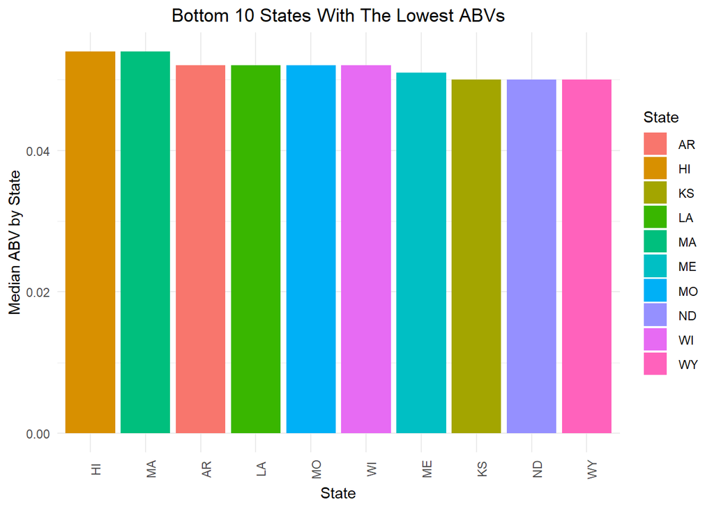

```r
#Bottom 10 ABV Graph
ggplot(Bottom10_Medianabv, aes(x=reorder(State,-MedABV),y=MedABV,fill=State)) + geom_bar(stat = "identity") + theme_minimal() + theme(axis.text.x = element_text(angle=90),plot.title = element_text(hjust=0.5)) + labs(x="State", y="Median ABV by State", title = "Bottom 10 States With The Lowest ABVs")
```

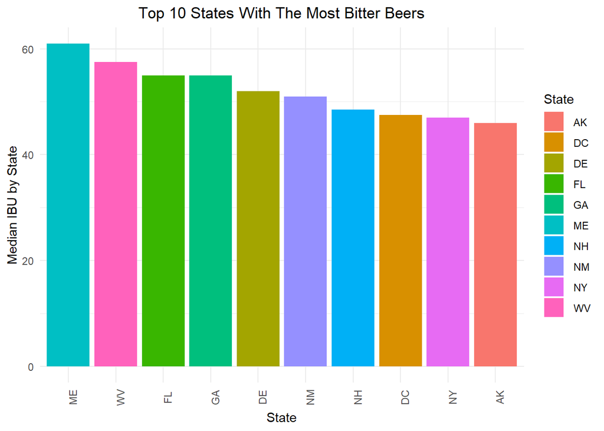

```r
#full plot
#ggplot(medabv, aes(x=reorder(State,-MedABV),y=MedABV,fill=State)) + geom_bar(stat = "identity") + theme_minimal() + theme(axis.text.x = element_text(angle=90,size=7),plot.title = element_text(hjust=0.5)) + labs(x="State", y="Median ABV by State", title = "Median ABV by State")

#Top 10 IBU Graph
ggplot(Top10_Medianibu, aes(x=reorder(State,-MedIBU),y=MedIBU,fill=State)) + geom_bar(stat = "identity") + theme_minimal() + theme(axis.text.x = element_text(angle=90),plot.title = element_text(hjust=0.5)) + labs(x="State", y="Median IBU by State", title = "Top 10 States With The Most Bitter Beers")
```

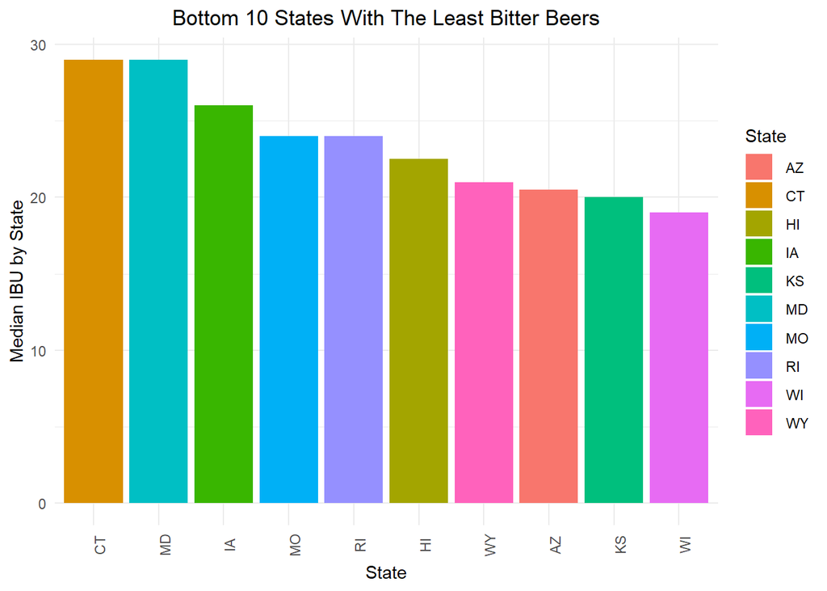

```r
#Bottom 10 IBU Graph
  ggplot(Bottom10_Medianibu, aes(x=reorder(State,-MedIBU),y=MedIBU,fill=State)) + geom_bar(stat = "identity") + theme_minimal() + theme(axis.text.x = element_text(angle=90),plot.title = element_text(hjust=0.5)) + labs(x="State", y="Median IBU by State", title = "Bottom 10 States With The Least Bitter Beers")
```

```r
#full ibu list
 #ggplot(medibu, aes(x=reorder(State,-MedIBU),y=MedIBU,fill=State)) + geom_bar(stat = "identity") + theme_minimal() + theme(axis.text.x = element_text(angle=90,size=7),plot.title = element_text(hjust=0.5)) + labs(x="State", y="Median IBU by State", title = "Median IBU by State")

#GraphByState <- MediansByState %>% ggplot(aes(x=State,y=MedABV)) + geom_bar(stat="identity") + coord_flip() #SD doesn't have IBU
```

## Max ABV and IBU

R Code here takes our combined data frame and sorts by the highest score for ABV and highest Score for IBU.

The state with the highest ABV score for a single beer is Colorado, the home of the Lee Hill Series Volume 5, the Belgian Style Quadrupel Ale, from Upslope Brewing Company in Boulder.

The state with the higest IBU score for a single beer is Oregon, which is home to the Bitter Bitch Imperial IPA out of the Astoria Brewing Company in Astoria, Oregon.

```r
#State for max ABV & max IBU
Combined[which.max(Combined$ABV),]
```

```
##     Brew_ID                                            Beer Name Beer_ID
## 375      52 Lee Hill Series Vol. 5 - Belgian Style Quadrupel Ale    2565
##       ABV IBU            Style Ounces            Brewery_Name    City
## 375 0.128  NA Quadrupel (Quad)   19.2 Upslope Brewing Company Boulder
##     State
## 375    CO
```

```r
Combined[which.max(Combined$IBU),]
```

```
##      Brew_ID                 Beer Name Beer_ID   ABV IBU
## 1857     375 Bitter Bitch Imperial IPA     980 0.082 138
##                               Style Ounces            Brewery_Name    City
## 1857 American Double / Imperial IPA     12 Astoria Brewing Company Astoria
##      State
## 1857    OR
```

## Summary of ABV data

This R code pulls some of the standard summary statistics related to the ABV data available.

```r
#Summary of ABV
summary(Combined$ABV)
```

```
##    Min. 1st Qu.  Median    Mean 3rd Qu.    Max.    NA's
## 0.00100 0.05000 0.05600 0.05977 0.06700 0.12800      62
```

```r
range(Combined$ABV,na.rm=TRUE)
```

```
## [1] 0.001 0.128
```

```r
mode(Combined$ABV)
```

```
## [1] "numeric"
```

```r
str(Combined$ABV)
```

```
##  num [1:2410] 0.045 0.049 0.048 0.06 0.06 0.056 0.08 0.125 0.077 0.042 ...
```

## ABV by IBU relationship

As a bonus, we did a scatter plot of the predicted IBU value (since IBU was missing in 40% of our data) using our linear predicted values. Since our regression line includes state as a factor in predicting IBU (since we saw some trends with bitterness and state), we can factor that into our trend line to make some interesting variance around the regression line.

For the sake of fun, lets see how our bitterness chart of our predicted data compares to the real data.

```r
#Is there an apparent relationship between the bitterness of the beer and its alcoholic content?
#Scatter <- ggplot(Combined, aes(x=ABV, y=IBU)) + geom_point()
#Scatter
cor.test(Combined$ABV,Combined$IBU) #P value is very low, Rejecting the null hypothesis saying that there is not a coorrelation. Pvalue is less than 0.001.
```

```
##
##  Pearson's product-moment correlation
##
## data:  Combined$ABV and Combined$IBU
## t = 33.863, df = 1403, p-value < 2.2e-16
## alternative hypothesis: true correlation is not equal to 0
## 95 percent confidence interval:
##  0.6407982 0.6984238
## sample estimates:
##       cor
## 0.6706215
```

```r
mylm <- lm(Combined$ABV~Combined$IBU, data = Combined)

summary(mylm)
```

```
##
## Call:
## lm(formula = Combined$ABV ~ Combined$IBU, data = Combined)
##
## Residuals:
##       Min        1Q    Median        3Q       Max
## -0.033288 -0.005946 -0.001595  0.004022  0.052006
##
## Coefficients:
##               Estimate Std. Error t value Pr(>|t|)
## (Intercept)  4.493e-02  5.177e-04   86.79   <2e-16 ***
## Combined$IBU 3.508e-04  1.036e-05   33.86   <2e-16 ***
## ---
## Signif. codes:  0 '***' 0.001 '**' 0.01 '*' 0.05 '.' 0.1 ' ' 1
##
## Residual standard error: 0.01007 on 1403 degrees of freedom
##   (1005 observations deleted due to missingness)
## Multiple R-squared:  0.4497, Adjusted R-squared:  0.4493
## F-statistic:  1147 on 1 and 1403 DF,  p-value: < 2.2e-16
```

```r
#run a regression using state and ABV as predictors
reg <- lm(IBU ~ ABV + State, data = Combined)

summary(reg)
```

```
##
## Call:
## lm(formula = IBU ~ ABV + State, data = Combined)
##
## Residuals:
##     Min      1Q  Median      3Q     Max
## -74.943 -11.235  -0.793  12.187  87.652
##
## Coefficients:
##              Estimate Std. Error t value Pr(>|t|)
## (Intercept)  -32.4592     5.0741  -6.397 2.18e-10 ***
## ABV         1305.5567    38.5033  33.908  < 2e-16 ***
## State AL       2.4468     7.8049   0.313   0.7540
## State AR      19.2369    19.4835   0.987   0.3236
## State AZ     -12.0258     6.0021  -2.004   0.0453 *
## State CA      -3.3643     4.8772  -0.690   0.4904
## State CO      -4.7559     4.8613  -0.978   0.3281
## State CT     -10.0455     8.9915  -1.117   0.2641
## State DC       2.8480    10.5224   0.271   0.7867
## State DE      12.6536    19.4736   0.650   0.5159
## State FL      -2.8224     5.5510  -0.508   0.6112
## State GA       2.2766     8.4994   0.268   0.7889
## State HI      -5.6643     6.4008  -0.885   0.3763
## State IA     -13.0920     5.9514  -2.200   0.0280 *
## State ID       9.4739     6.4927   1.459   0.1448
## State IL      -4.1448     5.5019  -0.753   0.4514
## State IN      -7.8061     5.0089  -1.558   0.1194
## State KS      -3.2119     6.3181  -0.508   0.6113
## State KY     -11.1282     6.8377  -1.627   0.1039
## State LA      -4.9103     7.5426  -0.651   0.5152
## State MA      -3.0615     5.3000  -0.578   0.5636
## State MD      -7.5075     7.5427  -0.995   0.3198
## State ME       5.3044     8.5012   0.624   0.5328
## State MI      -6.0796     5.5223  -1.101   0.2711
## State MN       3.5147     5.3741   0.654   0.5132
## State MO      -3.9374     5.7823  -0.681   0.4960
## State MS       2.0046     7.3238   0.274   0.7843
## State MT      -0.5457     6.0532  -0.090   0.9282
## State NC      -7.7094     5.7528  -1.340   0.1804
## State ND       2.2925    11.8515   0.193   0.8466
```

[output cut: 13 more lines]

```
## State TX      -5.9063     5.0117  -1.179   0.2388
## State UT       4.8935     7.3230   0.668   0.5041
## State VA       2.7798     5.5949   0.497   0.6194
## State VT       0.4902     6.4912   0.076   0.9398
## State WA       1.9869     5.4222   0.366   0.7141
## State WI     -11.4311     5.4408  -2.101   0.0358 *
## State WV       9.0147    14.1490   0.637   0.5241
## State WY      -6.2839     7.1358  -0.881   0.3787
## ---
## Signif. codes:  0 '***' 0.001 '**' 0.01 '*' 0.05 '.' 0.1 ' ' 1
##
## Residual standard error: 18.92 on 1354 degrees of freedom
##   (1005 observations deleted due to missingness)
## Multiple R-squared:  0.4872, Adjusted R-squared:  0.4683
## F-statistic: 25.73 on 50 and 1354 DF,  p-value: < 2.2e-16
```

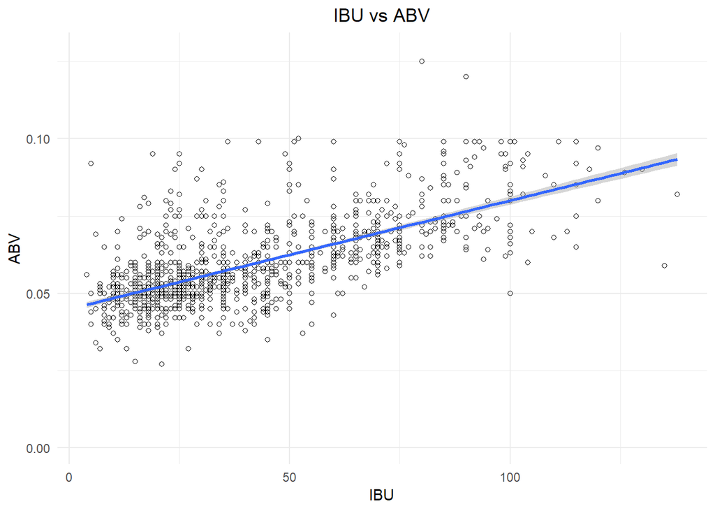

```r
#plot of real ABV and IBU data
#plot(ABV ~ IBU, data = Combined, main = "IBU vs ABV", xlab= 'ABV', ylab = 'IBU') + abline(reg, col="blue")

ggplot(Combined, aes(x=IBU, y=ABV)) +
    geom_point(shape=1) +    # Use hollow circles
    geom_smooth(method=lm) + # Add linear regression line
    theme_minimal() +
    theme(plot.title = element_text(hjust=0.5)) + labs(x="IBU", y="ABV", title = "IBU vs ABV")
```

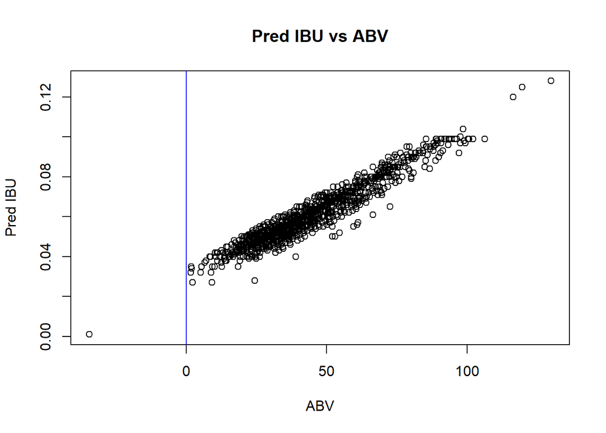

```
## integer(0)
```

```r
## let's see if we can use our regression to predict the IBU per state
#create a new variable for combined
Combine1 <- Combined
Combine1 <- Combine1[!Combine1$State==' SD',]
Combine1 <- Combine1[!Combine1$Brewery_Name=='Blackrocks Brewery',]

#use fit to predict the value
Combine2 <- Combine1 %>% mutate(pred = predict(reg, .)) %>%
  mutate (IBU = ifelse(is.na(IBU), pred, IBU)) #Replace NA with pred in IBU

Combine3 <- Combine2 %>% as.data.frame()



#plot of ABV and predicted IBU data
plot(ABV ~ pred, data = Combine3, main = "Pred IBU vs ABV", xlab= 'ABV', ylab = 'Pred IBU') + abline(reg, col="blue")
```

```r
# To verify our initial regression line, we leverage a forecast regression line and can see a similar output for the trend. As the IBU increases so does the ABV.
```

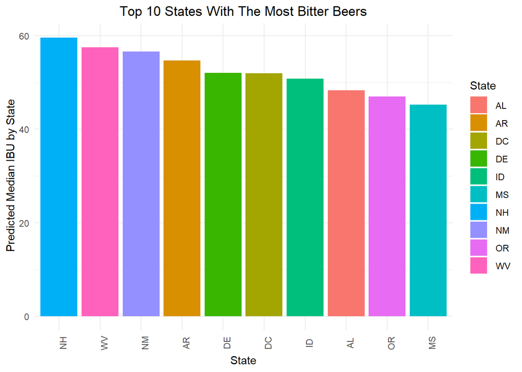

```r
#What is the median ABV & IBU by State without NAs
MediansByState2 <- Combine2 %>% group_by(State) %>% dplyr::summarise(MedIBUp = median(pred, na.rm=TRUE),MedABV= median(ABV, na.rm=TRUE))

#Subsetting the Ibu data into top/bottoms
medibu2 <- MediansByState2 %>% arrange(desc(MedIBUp))
Top10_Medianibu2 = subset(medibu2[1:10,])
Bottom10_Medianibu2 = subset(medibu2[41:50,])


#Top 10 IBU Graph
ggplot(Top10_Medianibu2, aes(x=reorder(State,-MedIBUp),y=MedIBUp,fill=State)) + geom_bar(stat = "identity") + theme_minimal() + theme(axis.text.x = element_text(angle=90),plot.title = element_text(hjust=0.5)) + labs(x="State", y=" Predicted Median IBU by State", title = "Top 10 States With The Most Bitter Beers")
```

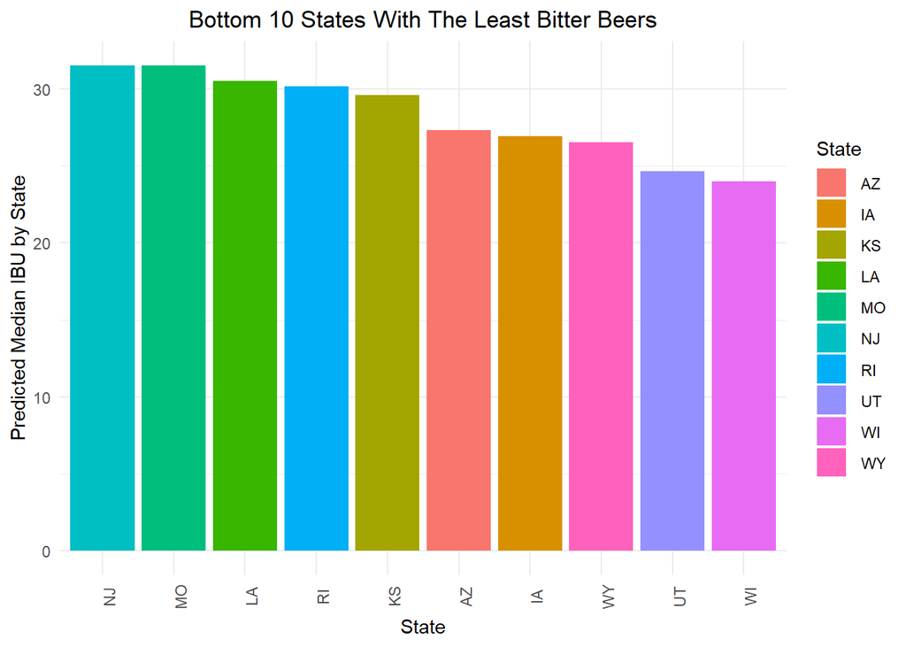

```r
#Bottom 10 IBU Graph
  ggplot(Bottom10_Medianibu2, aes(x=reorder(State,-MedIBUp),y=MedIBUp,fill=State)) + geom_bar(stat = "identity") + theme_minimal() + theme(axis.text.x = element_text(angle=90),plot.title = element_text(hjust=0.5)) + labs(x="State", y="Predicted Median IBU by State", title = "Bottom 10 States With The Least Bitter Beers")
```

```r
#full ibu list
#  ggplot(medibu, aes(x=reorder(State,-MedIBU),y=MedIBU,fill=State)) + geom_bar(stat = "identity") + theme_minimal() + theme(plot.title = element_text(hjust=0.5)) + labs(x="State", y="Median IBU by State", title = "Median IBU by State")

#GraphByState <- MediansByState %>% ggplot(aes(x=State,y=MedABV)) + geom_bar(stat="identity") + coord_flip() #SD doesn't have IBU
```

## Conclusion

From the implications to the research question standpoint, if AB Inbev were want to expand to underserved markets for micro-brews, AB would be able to know exactly what bitterness and ABV relationship is common in each market and be able to enter with an offering that will disrupt the current marketplace.

### You can find our published repository on https://github.com/GraceLang1110/SMU_MSDS_Github/tree/master/CaseStudy01